# Problem_Set_5

Zongyi Liu

2023-11-15

> The Github link for this assignment: https://github.com/zongyiliu/5_1_STATS_506/tree/main/Problem_Set_5

# Problem 1 Plotting NNMAPS

Use the `nnmaps` data set again. I’d recommend using `ggplot2` for these.

### Question a

Produce a graph of the `mean` monthly temperature in celsius. Draw a scatter-plot where the x-axis is month and the y-axis is the average monthly temperature in celsius. Add a line connecting the points within each season and color the lines and points by season (same color for lines and points in the same season). Be sure both x-axis and the legend are ordered appropriately, and that all labels/titles are clear and ready for publication (e.g. no variable names).

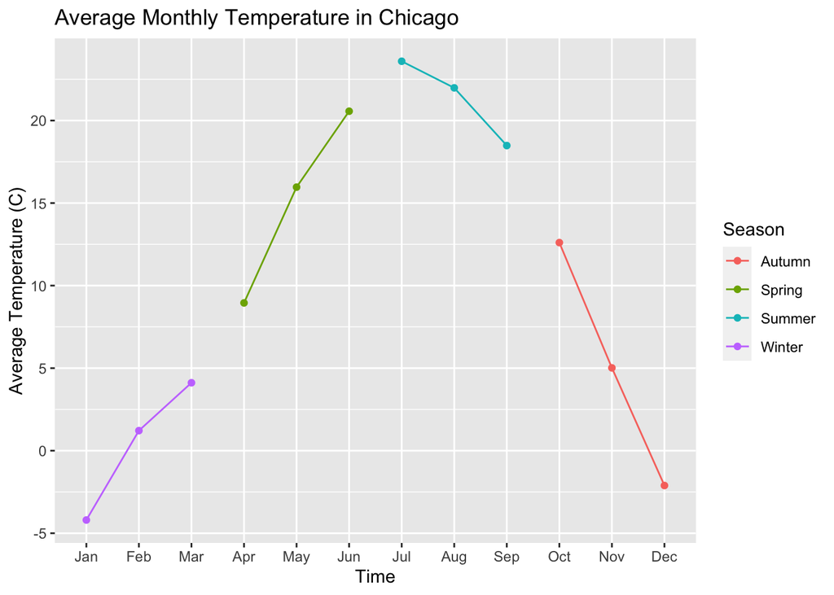

```r
data_use<-read.csv("chicago-nmmaps.csv")
#data_use
library(ggplot2)
library(dplyr)
data_use_2<-data_use%>%mutate(
  temp_cel=(temp-32)*5/9,
  date = as.POSIXct(date, format = "%Y-%m-%d"),
  year_month = format(date, "%Y-%m")
)%>%group_by(month,season)

# Reorder the month column
# data_use_2$month%>%reorder(order = month.abb)

data_use_2$month <- factor(data_use_2$month, levels = month.abb)

data_use_3<-data_use_2%>%summarise(avg_temp_cel=mean(temp_cel))
ggplot(data_use_3, aes(x = month, y = avg_temp_cel, color = season, group = season)) +
    geom_point() +
    geom_line() +
    labs(
        x = "Time",
        y = "Average Temperature (C)",
        title = "Average Monthly Temperature in Chicago",
        color = "Season"
    )
```

### Question b

Produce a similar plot with four sets of lines: mean monthly temperature in celsius, mean monthly O3, mean monthly PM10, and mean monthly dewpoint. Figure out a way to distinguish between the four lines. Again, make sure the plot is publication-ready (clean and clear labels). Use the plot to answer the following question: “Which of the four variables seems to have the least seasonal trend?”

```r
data_use_4<-data_use_2%>%
  group_by(month,season)%>%
  summarise(
    avg_temp_cel=mean(temp_cel,na.rm = T),
    avg_O3 = mean(o3, na.rm =T),
    avg_PM10 = mean(pm10, na.rm =T),
    avg_dewpoint = mean(dewpoint, na.rm = T)
    )
data_use_4
```

```
## # A tibble: 12 × 6
## # Groups:   month [12]
##    month season avg_temp_cel avg_O3 avg_PM10 avg_dewpoint
##    <fct> <chr>         <dbl>  <dbl>    <dbl>        <dbl>
##  1 Jan   Winter        -4.20  11.4      27.2         19.4
##  2 Feb   Winter         1.21  16.1      27.7         27.6
##  3 Mar   Winter         4.12  23.0      26.5         29.3
##  4 Apr   Spring         8.95  22.2      30.8         35.8
##  5 May   Spring        16.0   25.6      36.6         48.8
##  6 Jun   Spring        20.6   27.9      35.3         58.3
##  7 Jul   Summer        23.6   28.3      36.7         62.8
##  8 Aug   Summer        22.0   23.0      32.9         62.3
##  9 Sep   Summer        18.5   20.2      36.1         54.0
## 10 Oct   Autumn        12.6   13.3      38.9         43.5
## 11 Nov   Autumn         5.02  10.4      30.0         32.0
## 12 Dec   Autumn        -2.11   9.32     26.1         21.9
```

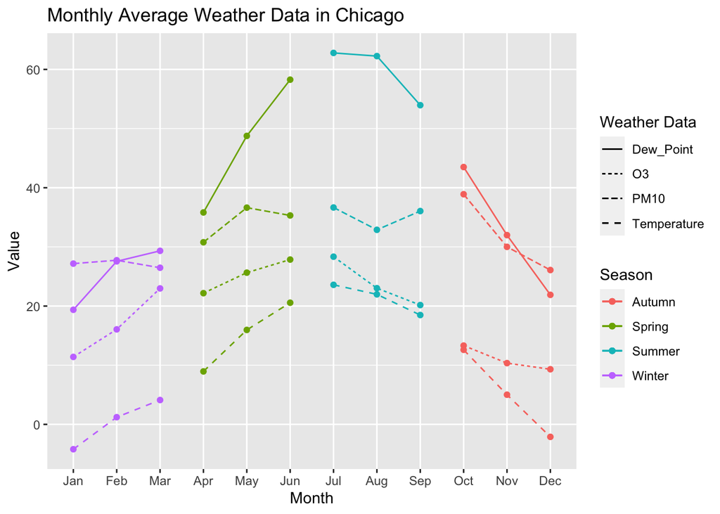

```r
# Totally the same as before
ggplot(data_use_4) +
    geom_point(aes(x = month, y = avg_temp_cel, color = season)) +
    geom_line(aes(x = month, y = avg_temp_cel, color = season, group = season, linetype = "Temperature")) +
    geom_point(aes(x = month, y = avg_O3, color = season)) +
    geom_line(aes(x = month, y = avg_O3, color = season, group = season, linetype = "O3")) +
    geom_point(aes(x = month, y = avg_PM10, color = season)) +
    geom_line(aes(x = month, y = avg_PM10, color = season, group = season, linetype = "PM10")) +
    geom_point(aes(x = month, y = avg_dewpoint, color = season)) +
    geom_line(aes(x = month, y = avg_dewpoint, color = season, group = season, linetype = "Dew_Point")) +
    labs(
        x = "Month",
        y = "Value",
        title = "Monthly Average Weather Data in Chicago",
        color = "Season",
        linetype = "Weather Data",
        shape="Weather Data"
    )
```

> In this plot, from top to bottom are `Dew Point`, `PM 10`, `O3`, and `Temperature`.

> From the plot we can say that PM10 has the least seasonal trend

# Problem 2 **OOP Programming**

### Question a

Create a class to represent a polynomial expression called `poly`. Do this using S4.

For the `poly` class, define the following:

- A constructor
- A validator
- A `show` method
- Addition and substraction

Very minor extra credit for ensuring that `show` reduces noice by

- 1. reducing $x^1$ and $x^0$ to $x$ and $1$ as appropriate, and
- 2. suppressing terms with coefficients of 0.

```r
library(stringr)
```

```r
# 1_Define `poly` class
setClass("poly",
         slots = list(coefficients = "numeric",
                   exponents = "numeric"))


# 2_Set the Constructor

make_poly <- function(expression){
  # Parse the strings
  # And we need to judge the sign
  terms <- unlist(strsplit(expression,
                           split ="(?<=\\D)(?=[+-])|(?<=[+-])(?=\\D)",
                           perl = TRUE))
  coeffs <- numeric()
  exps <- numeric()

  for (term in terms){

    # If it's negative

    sign <- ifelse(grepl("^-", term), -1, 1)
    term <- gsub("^[+-]\\s*", "", term)

    # Assume that indeterminate is always "x"
    coeff <- ifelse(grepl("x", term), 1, 0)
    coeff <- ifelse(grepl("^\\d+", term), as.numeric(sub("x.*$", "", term)), coeff)
    coeff <- sign * coeff

    exp <- ifelse(grepl("x", term), 1, 0)
    exp <- ifelse(grepl("x\\^", term), as.numeric(sub(".*\\^", "", term)), exp)

    coeffs <- c(coeffs, coeff)
    exps <- c(exps, exp)
  }

  # Create the new term
  new("poly", coefficients = coeffs, exponents = exps)
}


# 3_Set the Validator

setValidity("poly", function(object){

  # Check if coefficients and exponents have the same length
  if(length(object@coefficients) != length(object@exponents)) {
    stop("Coefficients and exponents should have the same length")

  # Check if exponents are non-neg integers
  if (any(object@exponents < 0) || any(object@exponents != as.integer(object@exponents)))
    return("Exponents must be Non-negative Integers")

    # Check if coeffs are numeric
    if (!is.numeric(object@coefficients))
        return("Coefficients must be Numeric")
    TRUE
  }

  return(TRUE)
})
```

```
## Class "poly" [in ".GlobalEnv"]
##
## Slots:
##
## Name:  coefficients    exponents
## Class:      numeric      numeric
```

```r
# 4_Define the Show Methods

setMethod("show", "poly", function(object){

  # Reorder terms
  new_order <- order(object@exponents, decreasing = TRUE)
  newly_ordered__coeffs <- object@coefficients[new_order]
  newly_ordered__exps <- object@exponents[new_order]

  unique_exps <- unique(newly_ordered__exps)
  new_coeffs <- sapply(unique_exps, function(exp){
    sum(newly_ordered__coeffs[newly_ordered__exps == exp])
  })

  terms <- mapply(function(coeff, exp){
    if (coeff == 0){
      return(NULL)
    } else if (exp == 0){
      return(as.character(coeff))
    } else if (exp == 1){
      return(ifelse(coeff == 1, "x", ifelse(coeff == -1, "-x", paste0(coeff, "x"))))
    } else{
      return(ifelse(coeff == 1, paste0("x^", exp),
                    ifelse(coeff == -1, paste0("-x^", exp),
                           paste0(coeff, "x^", exp))))
    }
  }, new_coeffs, unique_exps, SIMPLIFY = FALSE)

  # remove NULL terms
  terms <- Filter(Negate(is.null), terms)

  # Add back the new polynomial terms
  new_string <- paste(terms, collapse = " ") # Use gsub() to replace all occurrence of specific texts
  new_string <- gsub(" ([^\\-])", " + \\1", new_string)
  new_string <- gsub("-", "- ", new_string)
  cat(new_string, "\n")

  return(invisible(object))
})


# 5_Define the Addition Method

setMethod("+", signature("poly", "poly"), function(e1, e2){
  # Combine exponents and coefficients
  exponents_aggr <- unique(c(e1@exponents, e2@exponents))
  new_coeffs <- numeric(length(exponents_aggr))

  # Add the term with the same exponents together
  for (exp in exponents_aggr){
    new_coeffs[which(exponents_aggr == exp)] <-sum(e1@coefficients[e1@exponents == exp],
                                              e2@coefficients[e2@exponents == exp])
  }

  # Reorder the terms
  new_order <- order(exponents_aggr, decreasing = TRUE)
  new_coeffs <- new_coeffs[new_order]
  exponents_aggr <- exponents_aggr[new_order]

  # Create the new term
  new("poly", coefficients = new_coeffs, exponents = exponents_aggr)
})


# 6_define the Subtraction Method

# The same as before
setMethod("-", signature("poly", "poly"), function(e1, e2){
  # Combine exponents and coefficients
  exponents_aggr <- unique(c(e1@exponents, e2@exponents))
  new_coeffs <- numeric(length(exponents_aggr))
  # Add the term with the same exponents together
  for (exp in exponents_aggr) {
    new_coeffs[which(exponents_aggr == exp)] <- sum(e1@coefficients[e1@exponents == exp],
                                              -e2@coefficients[e2@exponents == exp])
  }
  # Reorder the terms
  new_order <- order(exponents_aggr, decreasing = TRUE)
  new_coeffs <- new_coeffs[new_order]
  exponents_aggr <- exponents_aggr[new_order]

  # Create the new term
  new("poly", coefficients = new_coeffs, exponents = exponents_aggr)
})
```

### Question b

Use your `poly` class to run the following code:

```r
p1 <- make_poly("3x^2 + 2")
p2 <- make_poly("7x^3 - 2x^2 - x + 17")
p1
```

```
## 3x^2
```

```r
p2
```

```
## 7x^3 + x^2 + x
```

```r
p1 + p2
```

```
## 7x^3 + 4x^2 + x
```

```r
p1 - p2
```

```
## - 7x^3 + 2x^2 - x
```

```r
# Just a note: NAs introduced by coercion3x^2 + 2
```

# Problem 3 NYCFlights 13

### Question a

Use the **tidyverse** for this problem. In particular, use piping and **dplyr** as much as you are able. **Note**: Use of any deprecated functions will result in a point loss.

Install and load the package [**nycflights13**](https://cran.r-project.org/package=nycflights13).

Generate a table (which can just be a nicely printed tibble) reporting the mean and median departure delay per airport. Generate a second table (which again can be a nicely printed tibble) reporting the mean and median arrival delay per airport. Exclude any destination with under 10 flights. Do this exclusion through code, not manually.

Additionally,

- Order both tables in descending mean delay.
- Both tables should use the airport *names* not the airport *codes*.
- Both tables should print all rows.

```r
# install.packages("data.table")
library(nycflights13)
library(data.table)
# Import tibble as data.table
flights_dt <- as.data.table(flights)
airports_dt <- as.data.table(airports)

# Exclude any destination with under 10 flights
destination_1 <- flights_dt[, .N, by = .(origin)][N >= 10, origin]

filtered_flights <- flights_dt[origin %in% destination_1]

departure_delay <- filtered_flights[, .(mean_dep_delay = mean(dep_delay, na.rm = TRUE),
                                        median_dep_delay = median(dep_delay, na.rm = TRUE)
                                    ), by = .(origin)]

# Add airport names
departure_delay <- airports_dt[departure_delay, on = .(faa = origin),
                                .(name, mean_dep_delay, median_dep_delay)]

# Order by mean departure delay
departure_delay <- departure_delay[order(-mean_dep_delay)]
departure_delay
```

```
##                   name mean_dep_delay median_dep_delay
## 1: Newark Liberty Intl       15.10795               -1
## 2: John F Kennedy Intl       12.11216               -1
## 3:          La Guardia       10.34688               -3
```

> The result is the same as I got in Problem Set 4

```r
# Edit the arr_delay columns in flights_dt

arrival_delay <- flights_dt[, .(
  mean_delay = mean(arr_delay, na.rm = TRUE),
  med_delay = median(arr_delay, na.rm = TRUE),
  numf_lights = .N
), by = .(dest)]

# Exclude any destination with under 10 flights
arrival_delay <- arrival_delay[numf_lights >= 10]

# Join with airports data to get airport names
arrival_delay <- merge(arrival_delay, airports_dt,
                          by.x = "dest", by.y = "faa", all.x = TRUE)

# There are some NA entries in names, we need to replace them with FAA codes. If we do not do so, there would be 105 colummns in the final result
arrival_delay[, name := fcoalesce(name, dest)]

# Reorder the column
arrival_delay <- arrival_delay[, .(name,
                                         mean_delay,
                                         med_delay)][order(-mean_delay)]

# Print
arrival_delay
```

```
##                           name mean_delay med_delay
##   1:     Columbia Metropolitan  41.764151      28.0
##   2:                Tulsa Intl  33.659864      14.0
##   3:         Will Rogers World  30.619048      16.0
##   4:      Jackson Hole Airport  28.095238      15.0
##   5:             Mc Ghee Tyson  24.069204       2.0
##  ---
##  98:       Seattle Tacoma Intl  -1.099099     -11.0
##  99:             Honolulu Intl  -1.365193      -7.0
## 100:                       STT  -3.835907      -9.0
## 101: John Wayne Arpt Orange Co  -7.868227     -11.0
## 102:         Palm Springs Intl -12.722222     -13.5
```

> There are 102 rows; the same as before.

### Question b

How many flights did the aircraft model with the fastest average speed take? Produce a tibble with 1 row, and entries for the model, average speed (in MPH) and number of flights.

```r
# Import as data table
planes_dt <- as.data.table(planes)

# Join the table
flights_planes_dt <- flights_dt[planes_dt, on = .(tailnum),nomatch = 0]

flights_planes_dt[, c("air_time", "distance") := list(as.numeric(air_time),
                                                     as.numeric(distance))]

## As we did before, we can not directly utilize the speeed variable becasue there would incur NA values. Thus we need to calculate speed in mph here
flights_planes_dt[!is.na(time) & !is.na(distance),
                 mph := distance / (air_time / 60)]
# Calculate average speed and number of flights
avg_speed <- flights_planes_dt[, .(
  avg_speed = mean(mph, na.rm = TRUE),
  num_flights = .N
  ), by = .(model)]

fastest_avg_speed<-avg_speed[order(-avg_speed)][1]

fastest_avg_speed
```

```
##      model avg_speed num_flights
## 1: 777-222  482.6254           4
```

> The result is the same as I got in Problem Set 4